# Assignement 1 Report

### Measurements

**The bandwidth and the latency estimation for gpu and thin nodes is done across cores, sockets and nodes**, with different protocols, PCI devices and libraries.

The nodes involved are:

- ct1pt-tnode007, thin node for results across cores, sockets and nodes.
- ct1pt-tnode008, thin node for results across nodes.
- ct1pg-gnode001, gpu node for results across cores, sockets and nodes.
- ct1pg-gnode003, gpu node for results across nodes.

**Each specific run is repeated 10 times** with `-msglog 28` and each time **for the thin ones the entire node was reserved** in order to reduce noise in measurements, **instead for the gpu nodes it wasn’t possible due to some queue traffic**. Thus, from the measurements, it was taken the mean time $\Delta t/2$ and the mean throughput $2X/\Delta t$ between the 10 results for each message size $X$, along with some statistics (ex. maximum error on time and on throughput $e = \frac{t_{max} - t_{min}}{2}$).

The PingPong benchmark is compiled on either the thin or gpu node using two different libraries:

- **OpenMPI**: version **openmpi-4.0.3** for the running across nodes with `UCX_NET_DEVICES` specification and latest **openmpi-4.1.1** for the others.
- **Intel MPI**: version `intel` available on ORFEO.

With **OpenMPI** implementation it is possible to specify the MPI frameworks and plugins (like pml and btl) that can be used while running. Across nodes, cores and sockets the following as been tested:

- *PML* : **ob1** and **ucx**.
- *BTL* : **tcp**, **self** and **vader**.

The following graphs show the results both for thin and gpu nodes from plotting the benchmark throupout $2X/\Delta t$ against the message size $X$ with different mappings of the processes: across two different nodes for the first plot and across two sockets or in the same socket for the latter.

Along with the results of ‘across nodes’ mapping, there has been drawn the lines for the 100 Gbit InfiniBand and 25 Gbit Ethernet, in order to compare the theoretical peak performances with the tested ones.

Moreover, in the plot ‘by socket/core’ mapping, cache size lines have been drawn too in order to discuss about a general behavior.

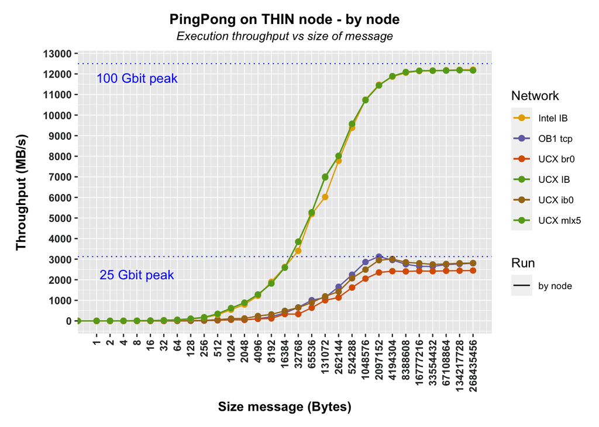

**IPoIB** (aka UCX ib0) happen to have a good latency (see table in ‘Results’ section) but the bandwidth is not so high and in fact it is comparable to the one of the 25 Gbit Ethernet network.

Now let’s look at the performance with the across core and socket configuration.

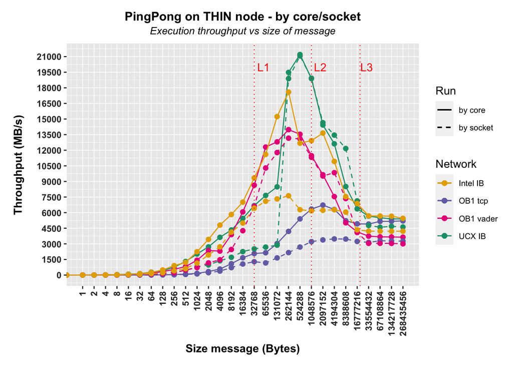

From first glance it is clear that these performance are smaller in bandwith, but better in latency (see table in ‘Report section’) when compared to across nodes configuration. Moreover, **mapping the processes in the same socket show often a better performance than mapping them in separate sockets** .

By plotting the cache lines it is clear that this behavior **must be related to the cache**: in fact, when the size of the PingPong message becomes too large to fit in **L1**, there’s an L1 miss and data are retrieved from cache **L2**. This happens too for L2 as the size grows so there is a visible drop in the throughput. L1 effects is not clearly visible from the bandwidth ( probably due the latency ), instead for L2 misses after $1$ MB, all implementations start loosing bandwidth. In the plateau area, instead, the message size is larger than all caches and a stable bandwith is reached.

Now let’s have a look at the GPU results in terms of throughput.

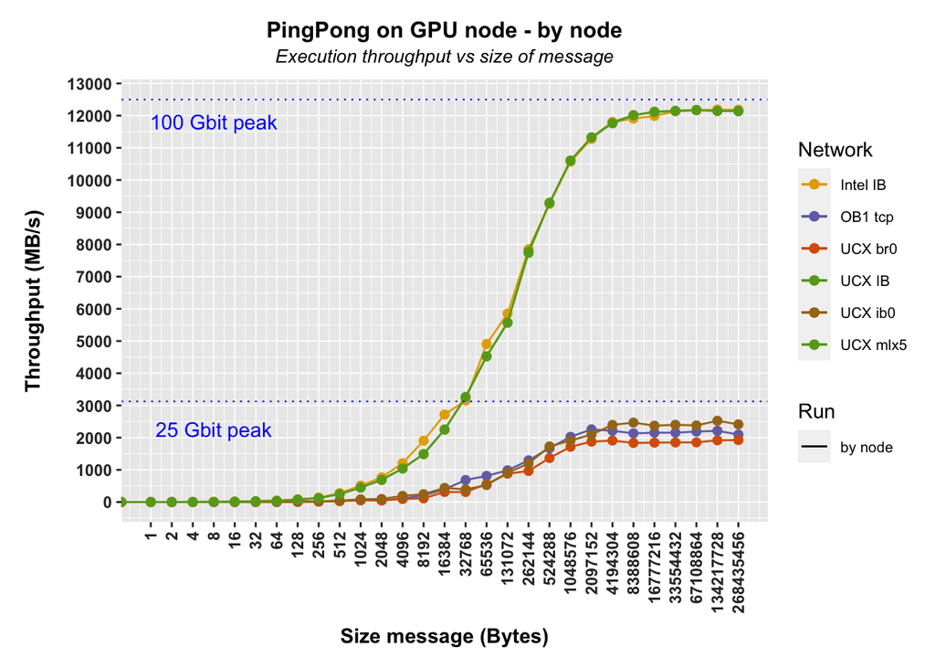

This can be caused either by the fact that not being able to reverse a whole node (if not 2 in the across node configuration) or, more likely, by the different CPU frequencies and node configurations: remember that even if gpu CPU has a theoretical higher maximum frequency (2.70GHz) with respect to the one of the thin node (2.60GHz), these frequencies are much smaller when running simultaneously on several cores.

Cache size are the same as thin node, then cache effects are similar, as it is shown here:

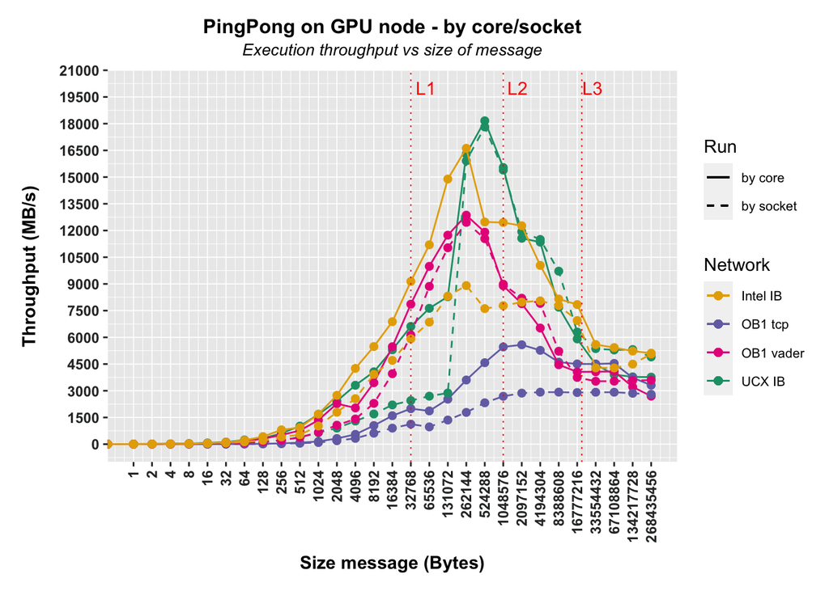

### Results

Here are shown the estimation via least square methods of the latency $\lambda_{net}$ and bandwidth $b_{net}$ of the networks used. To see the fit model estimation look in the folder *section2/mydata/csv-files/*.

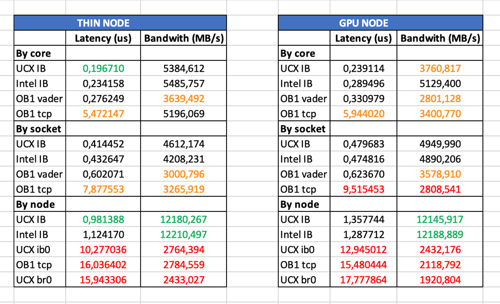

Latency and bandwith fit estimation

# Exercise 3

## Jacobi solver

It’s a prototype for as stencil-based iterative method used in numerical analysis to solve partial differential equations.

In its most straightforward form, it can be used for solving the diffusion equation for a scalar function $\Phi (r,t)$:

$$\frac{\delta \Phi}{\delta t} = \Delta \Phi$$
on a rectangular lattice subject to Dirichlet boundary conditions. The differential operators are discretized using finite differences:
$$\frac{\delta \Phi (x_i, y_i)}{\delta t} = \frac{\Phi (x_i+1, y_i)+\Phi (x_i-1, y_i)-2\Phi (x_i, y_i)}{\delta x^2} + \frac{\Phi (x_i+1, y_i+1)+\Phi (x_i, y_i-1)-2\Phi (x_i, y_i)}{\delta y^2}$$
In each time step, a correction $\delta \Phi$ to $\Delta \Phi$ at coordinate $(x_i,y_i)$ is calculated using the “old” values from the four next neighbor points. Of course, the updated $\Phi$ values must be written to a second array. After all points have been updated (a “sweep”), the algorithm is repeated till some basic convergence bounded by a threshold $eps$.

The following is a 2D Implementation of the Jacobi algorithm on an N × N lattice, with a convergence criterion added, taken by G.Hager and G.Wellein “Introduction to high performance computing for scientists and engineers”:

```bash
double precision, dimension(0:N+1,0:N+1,0:1) :: phi
double precision :: maxdelta,eps
  integer :: t0,t1
  eps = 1.d-14 ! convergence threshold
  t0=0;t1=1
  maxdelta = 2.d0*eps
  do while(maxdelta.gt.eps)
  maxdelta = 0.d0
do k = 1,N
  do i = 1,N
    phi(i,k,t1) = ( phi(i+1,k,t0) + phi(i-1,k,t0)
               + phi(i,k+1,t0) + phi(i,k-1,t0) ) * 0.25
    maxdelta = max(maxdelta,abs(phi(i,k,t1)-phi(i,k,t0)))
enddo
  enddo
! swap arrays
    i = t0 ; t0=t1 ; t1=i
enddo
```

In a parallel computation, the core of the code implementation is similar but:

- convergence criterion needs to be computed globally (collective reduce operations)
- boundary layers must retrieve info form adjacent subdomains (halo layers exchange) in order to update their values.

For this exercise, we used as **Jacobi solver 3D program given by the professor Cozzini written in FORTRAN**.

## Performance model

In order to predict 3D Jacobi model performance $P$ the following model has been used:
$$\begin{equation}
\tag{*}
P(L,N)=\frac{L^3N}{T_s(L)+T_c(L,N)}\space \bigg[ \frac{MLUP}{s} \bigg]
\end{equation}$$
where:

- $L$ is the subdomain size, assuming it’s a cube..
- $N= N_x N_y N_z$ is the number of the processes involved.
- $L^3N$ is the problem size. The amount of work, therefore, increase linearly as a function of $N$; hence a weak scalability will be considered.
- $MLUP/s$ is the unit for measuring this performance (Mega Lactice Updates Per sec).
- $T_s$ is the time for an entire sweep, thus it can estimated using the program as serial.
- $T_c$ represent the communication time for total halo exchanges.

The latter is modeled by simply estimating the latency $\lambda$, bandwidth $b$ of the network and messages size $c$.

In a 3D problem, the number of points used to estimate a point of the subdomain is not 4 (5 stencil case) but 6 instead (7 stencil case). When processes communicates whit each other they simultaneously sends each of the 6 point-to-point communication at the same time, so we need to consider full duplex data transfer for bandwidth.

Moreover we assume that the time for copying the halo to/from an intermediate buffer and the communication of a process with itself come at no costs. $T_c$ then can be model as:

$$\begin{equation}
\tag{**}
T_c(L,N)=\frac{c(L)}{b}+k\lambda\space [s]
\end{equation}$$

where:

- $c(L)$ is the amount of data volume transferred over a node’s network link.
- $b$ is the bidirectional bandwith of the network link
- $\lambda$ is the latency
- k is the largest number of coordinate directions in which $N_i > 1$.

Then $c$ is, :
$$\begin{equation}
\tag{***}
c(L)=L^2k\cdot2\cdot8\space [B]
\end{equation}$$

where:

- $k$ represents the number of directions in which the halo exchange occurs.
- $L^2$ is the halo surface to transmit.
- $2$ is for taking into account the bidirectional halo exchange.
- $8$ is for double conversion, assuming that the grid points in the subdomain are double floating points.

## Domain decomposition

Since we use a **3D Jacobi FORTRAN program (column-major order)**, there are domains decomposition that are more suitable than others when dealing with contiguous location in memory for halo exchange.

In order to find the best decomposition possible, several tests has been done in order to find the most performing permutation of ($N_x, N_y, N_z$).

**With $N=6$ take $(6,1,1)$ $(1,6,1)$ $(1,1,6)$ decompositions when $L=1200$ on a thin node: experimentally, the first configuration behave better** than the other in terms of MLUP/s (oss. use large values of $L$ to see this effect). Example:

| Mapping | Nx | Ny | Nx | MLUP/s |
| --- | --- | --- | --- | --- |
| core | 6 | 1 | 1 | 668 |
| core | 1 | 6 | 1 | 665 |
| core | 1 | 1 | 6 | 665 |
| socket | 6 | 1 | 1 | 674 |
| socket | 1 | 6 | 1 | 671 |
| socket | 1 | 1 | 6 | 670 |

**Instead when comparing always with $N=6$, $(6,1,1)$ and $(3,2,1)$ the first has more buffering cost involved but the latter has more halo exchanges, thus both the two configurations will be taken into account**.

## Results

As a first step I have tried to **compile and run the code on single processor of a thin and gpu node to estimate the serial time on one single core $T_s$**.

I have used **OpenMPI implementation on ORFEO both on thin and gpu nodes** using native IB protocol.

The **size of the subdomain $L=700$ was fixed and used both for gpu and thin** measurements since, due to RAM size on the gpu node (see `pbsnodes -ajS` in Exercise 2), it corrisponds to the maximum amount of memory availble for comparison between the two different nodes.

The Jacobi program was runned on:

- 4/8/12 processes within the same thin node pinning the MPI processes within the same socket.
- 4/8/12 processes within the same thin node pinning the MPI processes across two sockets.
- 12/24/48 processes using two thin nodes.
- 12/24/48 processes using one gpu node mapping by core (hyperthreading is enabled).
- 12/24/48 processes using one gpu node mapping by socket (hyperthreading is enabled).

**The *jacobi3D* program prints out the performance in $MLUP/s$ as last column for each run: I have taken the mean of the 10 results**. Along with the performance measurements, I took the elapsed time by means of `/usr/bin/time -f "user : %U system: %S elapsed: %e CPU: %P CMD: %C \n"` run command.

The following is an example of running with $L=700$ and $N=(4,1,1)$:

```bash
# Threadlevel provided:        3 out of        0        1        2        3
  spat_dim , proc_dim, PBC ?
           1 -Dim Input         2800           4 T
           2 -Dim Input          700           1 T
           3 -Dim Input          700           1 T
#   0 Process grid   4   1   1
           0           3           2
           2           3           2
           3           3           2
           1           3           2
#   0  Allocated 2 arrays with a total of  5535.17      Mbytes
# StartResidual    0.00000000000
  4  Maxtime , Mintime + JacobiMi , JacobiMa    3.06243716300        3.06242734200        2.98796024800        2.99414415400       Residual    12273333.3238      MLUPs    448.009192344
  4  Maxtime , Mintime + JacobiMi , JacobiMa    3.06078858000        3.06078676400        2.98838307400        2.99486265400       Residual    2041666.66667      MLUPs    448.250496282
  4  Maxtime , Mintime + JacobiMi , JacobiMa    3.06090752400        3.06090532700        2.98793178100        2.99505510000       Residual    434799.382550      MLUPs    448.233077688
  4  Maxtime , Mintime + JacobiMi , JacobiMa    3.06095547000        3.06095308700        2.98808474500        2.99490125800       Residual    129179.526716      MLUPs    448.226056683
  4  Maxtime , Mintime + JacobiMi , JacobiMa    3.06516349800        3.06516215100        2.99001243700        2.99797766000       Residual    52905.8427676      MLUPs    447.610706866
  4  Maxtime , Mintime + JacobiMi , JacobiMa    3.06256750200        3.06256510400        2.98815335100        2.99561585600       Residual    27258.4295825      MLUPs    447.990125639
  4  Maxtime , Mintime + JacobiMi , JacobiMa    3.06197104500        3.06196926100        2.98880531000        2.99486067300       Residual    16225.1238619      MLUPs    448.077391927
  4  Maxtime , Mintime + JacobiMi , JacobiMa    3.06272575000        3.06272477100        2.98845891200        2.99545644500       Residual    10594.4563848      MLUPs    447.966978434
  4  Maxtime , Mintime + JacobiMi , JacobiMa    3.06178146800        3.06177916200        2.98808213100        2.99487845400       Residual    7372.72712122      MLUPs    448.105135634
  4  Maxtime , Mintime + JacobiMi , JacobiMa    3.06086679800        3.06086465500        2.98821124300        2.99498761300       Residual    5375.90215905      MLUPs    448.239041600
```